# Exercise 05

Author

Gianfranco Botta (GianfrancoBotta)

Published

October 23, 2023

## Question 1

*How do these mappers (bowtie2 and STAR) score alignments?*

Bowtie2 and STAR use different scoring schemes to evaluate alignments. Bowtie2 uses a traditional alignment scoring scheme that is based on the number of mismatches and gaps in the alignment. The score for an alignment is calculated as follows:
$$score = matches * reward - mismatches * penalty1 - gaps * penalty2$$
where reward, penalty1 and penalty2 may be decided by the user, but they also have default values. For end-to-end alignments, mismatches of high quality positions are penalized with -6, while there is no bonus for a match. Gap openings are penalized with -5, while every extension of a gap is penalized with -3. For local alignments, mismatches mismatches of high quality positions are penalized with -6 as well, however, in a local alignment matches give a bonus of +2. Gap openings are penalized with -5, while every extension of a gap is penalized with -3.

STAR uses a more complex scoring scheme that takes into account not only the factors aforementioned in Bowtie2, but also splice junction penalty, indel opening penalty and indel extension penalty proportional to the indel length. All the scores can be user defined, but it provides some default values as well. For local alignments (default of STAR), matches are rewarded with +1, while mismatches are penalized with -1. The default splice junction penalty is 0, however, different penalties can be added. Non-canonical junctions as well as AT/AC and GT/AT junctions are penalized with -8. GC/AG and CT/GC junctions are penalized with -4. Deletion and insertion openings and extensions are penalized with -2. Furthermore, there is an extra score scaling logarithmically with the length of the alignment, which has a default value of -0.25.

## Question 2

*What reporting options are available?*

Aligners allow to choose different reporting strategies. As for Bowtie2, the available reporting options are three:

- default - Bowtie2 searches for distinct, valid alignments for each read. When it finds a valid alignment, it continues looking for alignments that are nearly as good or better. The best alignment found is reported (randomly selected from among best if tied).
- -k (int) - it searches for at most N distinct, valid alignments for each read. The search terminates when it can’t find more distinct valid alignments, or when it finds N, whichever happens first. All alignments found are reported in descending order by alignment score.
- -a - it is like -k but with no upper limit on number of alignments to search for. All alignments found are reported in descending order by alignment score.

As for STAR, it reports the alignment in a SAM file. Thereby, it differentiates between unique mappers (reads mapping only to one locus) and multi-mappers (mapping to more than 1 loci). Multi-mappers can be filtered out using the –outFilterMultimapNmax N parameter, which only outputs reads mapped to maximal N loci. The –outSAMmultNmax parameter specifies how many alignments are output for a given multi-mapper read. If –outSAMmultNmax -1, then all alignments are reported.

## Load packages

```r
library("BSgenome")
library("BSgenome.Scerevisiae.UCSC.sacCer3")
library("Rsubread")
library("ShortRead")
library("R.utils")
library("ggplot2")
library("knitr")
```

## Download the a read data file

```r
# Download th read data file
dir = "C:/Users/gianf/OneDrive/Documenti/DOCUMENTS_ETH/1 YEAR/1 SEMESTER/SAHTGTD/EXERCISES/Yeast_example"

if (!file.exists(dir)) {
  dir.create(dir)
  setwd(dir)
  options(timeout=120)
  download.file("http://fgcz-gstore.uzh.ch/public/Yeast_Reads/20170313.A-G3_R1-sub.fastq.gz", "G3_R1-sub.fastq.gz")
}

setwd(dir)
```

Now we read the fastq files containing the sequences to align to the reference genome.

```r
fastq_file <- "C:/Users/gianf/OneDrive/Documenti/DOCUMENTS_ETH/1 YEAR/1 SEMESTER/SAHTGTD/EXERCISES/Yeast_example/G3_R1-sub.fastq.gz"
fq <- readFastq(fastq_file)
head(fq)
```

```
class: ShortReadQ
length: 6 reads; width: 151 cycles
```

First, we have a look at the distribution of the average quality score in the reads.

```r
reads <- sread(fq)
widths <- reads@ranges@width

q <- quality(fq)
head(q)
```

```
class: FastqQuality
quality:
BStringSet object of length 6:
    width seq
[1]   151 AAAAA#EEEEAEEEEAEEEEAAEEEEEEEEEEEE...EE/6EEE/<<AE<<AA/AE////E<EE<AAAA<
[2]   151 AAAAA#EEEEEEEEEEEEEEEEEEEEEEEEEEEE...EEEEEEAEEEEEEAEEEEEAEAEEEEEAEEE<A
[3]   151 AAAAA#EEEEEEEAEEEEEEEE/EEEEEEEEAEE...EEEEEEEEEAEEEEE<AA<A<E<E<EEEEEEEE
[4]   151 6/AAA#EEEEEEEEEEEEEEEEAAEEAE/AEEEA...EEEAA6<</E</AEAE/AA////AA//<EA<</
[5]   151 AAAAA#EEA/EEEEEEEEE6EEEEEEEEEEEEEE...AAAEE/EE//<AEAEAE6EE<EAE</EEAAEA/
[6]   151 AAAAA#EEAEEAEEEEEEEEEEEEE/EEEEEEEE...EEE/AAEEEAEEEEEEEEEAE///<EEE/EA<A
```

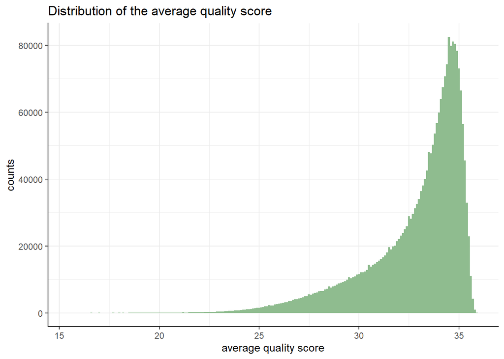

```r
# Transform quality scores in integers and find the average quality score
num_q <- as(q, 'matrix')
avg_q <- data.frame(Q = rowMeans(num_q))

ggplot(data = avg_q) +
  geom_histogram(aes(x = Q),
                 binwidth = 0.1,
                 fill = "darkseagreen") +
  theme_bw() +
  theme(
    panel.border = element_blank(),
    axis.line = element_line(color = "black", linewidth = 0.5, lineend = "square")
  ) +
  labs(x = "average quality score",
       y = "counts") +
ggtitle("Distribution of the average quality score")
```

From the histogram we notice that we have a average quality score acceptable in the majority of the reads, but we still deal with reads that present an average score below the acceptable threshold Q = 30. Let us try to understand if there is a systematic loss of quality in the first or in the last nucloeotides read.

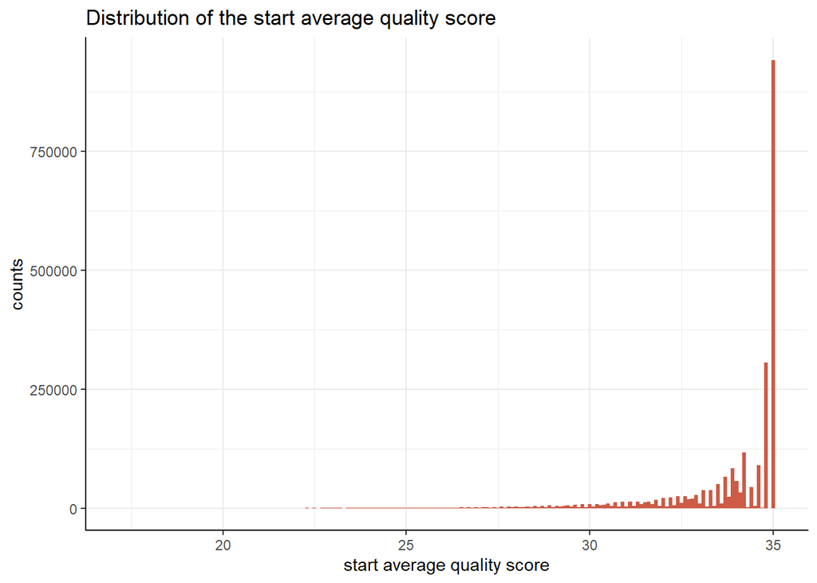

```r
start_q <- num_q[, 1:20]
end_q <- num_q[, (ncol(num_q)-20):ncol(num_q)]
start_avg_q <- data.frame(Start = rowMeans(start_q))
end_avg_q <- data.frame(End = rowMeans(end_q))

ggplot(data = start_avg_q) +
  geom_histogram(aes(x = Start),
                 binwidth = 0.1,
                 fill = "coral3") +
  theme_bw() +
  theme(
    panel.border = element_blank(),
    axis.line = element_line(color = "black", linewidth = 0.5, lineend = "square")
  ) +
  labs(x = "start average quality score",
       y = "counts") +
ggtitle("Distribution of the start average quality score")
```

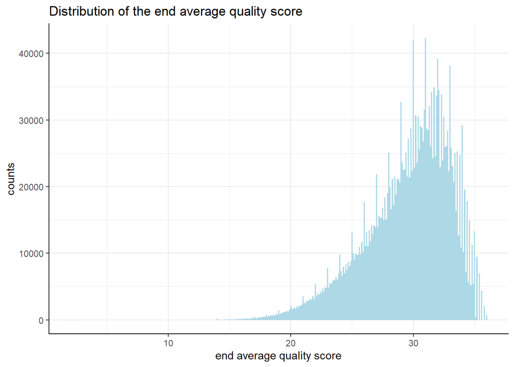

```r
ggplot(data = end_avg_q) +
  geom_histogram(aes(x = End),
                 binwidth = 0.1,
                 fill = "lightblue") +
  theme_bw() +
  theme(
    panel.border = element_blank(),
    axis.line = element_line(color = "black", linewidth = 0.5, lineend = "square")
  ) +
  labs(x = "end average quality score",
       y = "counts") +
ggtitle("Distribution of the end average quality score")
```

We asserted that the quality is very high at the start of the sequences, and although it is a little smaller at the end, we do not have to worry about it. Hence, no trimming is needed.

Use the commands export to export method in the BSgenome package to write the genome as a fasta file on the local disk. Use the commands buildindex and align of the Rsubread package to map the reads. Consult the help pages of the respective functions. Build the index so that at most 2GB of RAM is used. Run the alignment with 4 threads. If you computer has less resources, adapt accordingly.

```r
# Import the reference genome and index it
genome <- BSgenome.Scerevisiae.UCSC.sacCer3
fasta_genome <- file.path(tempdir(), "Scerevisiae.fasta")
export(genome, fasta_genome)
```

```
writing chrI sequence to file ... OK
writing chrII sequence to file ... OK
writing chrIII sequence to file ... OK
writing chrIV sequence to file ... OK
writing chrV sequence to file ... OK
writing chrVI sequence to file ... OK
writing chrVII sequence to file ... OK
writing chrVIII sequence to file ... OK
writing chrIX sequence to file ... OK
writing chrX sequence to file ... OK
writing chrXI sequence to file ... OK
writing chrXII sequence to file ... OK
writing chrXIII sequence to file ... OK
writing chrXIV sequence to file ... OK
writing chrXV sequence to file ... OK
writing chrXVI sequence to file ... OK
writing chrM sequence to file ... OK
```

```r
buildindex(basename = "ref_idx",
           reference = fasta_genome,
           gappedIndex = TRUE,
           indexSplit = TRUE,
           memory = 2000)
```

[output not shown]

[output cut: 18 more lines]

[output not shown]

We used the argument gappedIndex = TRUE in order to reduce the memory usage from 0.8GB to 0.6GB for the index of the genome. Furthermore we set memory = 2000 to specify that at most 2000MB (approximately 2GB as asked) of RAM is used.

## Question 3

*What is the fraction of reads aligned (unique and multi-mappers) of the reads?*

```r
setwd(dir)
align(index = "ref_idx",
      readfile1 = "G3_R1-sub.fastq.gz",
      nthreads=4)
```

[output not shown]

[output cut: 25 more lines]

```

//================================   Summary =================================\\
||                                                                            ||
||                 Total reads : 2386945                                      ||
||                      Mapped : 2183189 (91,5%)                              ||
||             Uniquely mapped : 1707585                                      ||
||               Multi-mapping : 475604                                       ||
||                                                                            ||
||                    Unmapped : 203756                                       ||
||                                                                            ||
||                      Indels : 8197                                         ||
||                                                                            ||
||                Running time : 0,6 minutes                                  ||
||                                                                            ||
\\============================================================================//
```

```
                      G3_R1-sub.fastq.gz.subread.BAM
Total_reads                                  2386945
Mapped_reads                                 2183189
Uniquely_mapped_reads                        1707585
Multi_mapping_reads                           475604
Unmapped_reads                                203756
Indels                                          8197
```

```r
summary_file <- readLines("C:/Users/gianf/OneDrive/Documenti/DOCUMENTS_ETH/1 YEAR/1 SEMESTER/SAHTGTD/EXERCISES/Yeast_example/G3_R1-sub.fastq.gz.subread.BAM.summary")

summary_file <- strsplit(summary_file, split = "\t")

statistics = unlist(lapply(summary_file, `[[`, 1))
values = unlist(lapply(summary_file, `[[`, 2))

n_reads <- as.numeric(values[1])
map_reads <- as.numeric(values[2])/n_reads*100
uniq_map_reads <- as.numeric(values[3])/n_reads*100
multi_map_reads <- as.numeric(values[4])/n_reads*100
unmap_reads <- as.numeric(values[5])/n_reads*100
indels <- as.numeric(values[6])/n_reads*100

percentages = rbind(100, map_reads, uniq_map_reads, multi_map_reads, unmap_reads ,indels)

summary_df = data.frame(statistics,
                        values,
                        percentages)

kable(summary_df)
```

|  | statistics | values | percentages |
| --- | --- | --- | --- |
|  | Total_reads | 2386945 | 100.0000000 |
| map_reads | Mapped_reads | 2183189 | 91.4637329 |
| uniq_map_reads | Uniquely_mapped_reads | 1707585 | 71.5385147 |
| multi_map_reads | Multi_mapping_reads | 475604 | 19.9252182 |
| unmap_reads | Unmapped_reads | 203756 | 8.5362671 |
| indels | Indels | 8197 | 0.3434097 |

## Question 4

*How does this mapping rate change if you trim 5 bases of both ends?*

```r
setwd(dir)
align(index = "ref_idx",
      readfile1 = "G3_R1-sub.fastq.gz",
      output_file=paste("G3_R1-sub.fastq.gz","trimmed","subread","BAM",sep="."),
      nthreads=4,
      nTrim5=5,
      nTrim3=5)
```

[output not shown]

[output cut: 25 more lines]

```

//================================   Summary =================================\\
||                                                                            ||
||                 Total reads : 2386945                                      ||
||                      Mapped : 2224294 (93,2%)                              ||
||             Uniquely mapped : 1730885                                      ||
||               Multi-mapping : 493409                                       ||
||                                                                            ||
||                    Unmapped : 162651                                       ||
||                                                                            ||
||                      Indels : 7983                                         ||
||                                                                            ||
||                Running time : 0,6 minutes                                  ||
||                                                                            ||
\\============================================================================//
```

```
                      G3_R1-sub.fastq.gz.trimmed.subread.BAM
Total_reads                                          2386945
Mapped_reads                                         2224294
Uniquely_mapped_reads                                1730885
Multi_mapping_reads                                   493409
Unmapped_reads                                        162651
Indels                                                  7983
```

```r
summary_t_file <- readLines("C:/Users/gianf/OneDrive/Documenti/DOCUMENTS_ETH/1 YEAR/1 SEMESTER/SAHTGTD/EXERCISES/Yeast_example/G3_R1-sub.fastq.gz.trimmed.subread.BAM.summary")

summary_t_file <- strsplit(summary_t_file, split = "\t")

statistics_trim = unlist(lapply(summary_t_file, `[[`, 1))
values_trim = unlist(lapply(summary_t_file, `[[`, 2))

n_reads_trim <- as.numeric(values_trim[1])
map_reads_trim <- as.numeric(values_trim[2])/n_reads_trim*100
uniq_map_reads_trim <- as.numeric(values_trim[3])/n_reads_trim*100
multi_map_reads_trim <- as.numeric(values_trim[4])/n_reads_trim*100
unmap_reads_trim <- as.numeric(values_trim[5])/n_reads_trim*100
indels_trim <- as.numeric(values_trim[6])/n_reads_trim*100

percentages_trim = rbind(100, map_reads_trim, uniq_map_reads_trim, multi_map_reads_trim, unmap_reads_trim ,indels_trim)

summary_df = data.frame(statistics_trim,
                        values_trim,
                        percentages_trim)

kable(summary_df)
```

|  | statistics_trim | values_trim | percentages_trim |
| --- | --- | --- | --- |
|  | Total_reads | 2386945 | 100.0000000 |
| map_reads_trim | Mapped_reads | 2224294 | 93.1858086 |
| uniq_map_reads_trim | Uniquely_mapped_reads | 1730885 | 72.5146579 |
| multi_map_reads_trim | Multi_mapping_reads | 493409 | 20.6711508 |
| unmap_reads_trim | Unmapped_reads | 162651 | 6.8141914 |
| indels_trim | Indels | 7983 | 0.3344442 |

We observe that the percentage of the mapped reads is 91.46% without trimming and 93.18% with trimming. Hence, having nTrim5 = 5 can allow to increase the mapping rate. In this case, we see an increase of multi-mapping reads from 475604 to 493409, as well as a decrease of unmapped reads from 203756 to 162651 and a decrease of indels from 8197 to 7983. As a consequence, we observe a certain improvement, but not so significant. This consideration fits perfectly with the one done before, after analyzing the distributions of the quality score at the beginning and at the end of the reads.